# L18 - Multivariate Classification

## Lecture Goals

- Work with multiple features
- Understand linear & nonlinear classification
- Perform multivariate classification in R with
  - *Logistic Regression*
  - *Classification Trees*

Readings - [ISLR](https://www-bcf.usc.edu/~gareth/ISL/ISLR%20Seventh%20Printing.pdf) ch 4.3-4 (optional)

## Multiple Features

- Information can be reflected in multiple variables
- **Feature Engineering**: which features should be *generated* from available information?
  - E.g. in WDBC features represent cell morphology
- **Feature Selection**: which features from *fixed* collection should one use?
  - Not always optimal to use *all* features

## WDBC Data

- Thresholding *individual* variable gives OK classifier
- Can it improve by combining *multiple* variables?

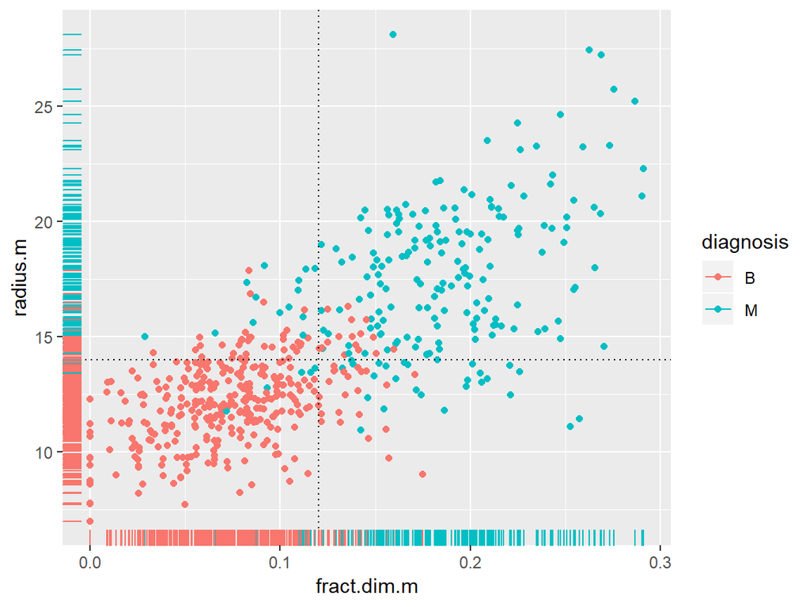

## Linear Classifiers

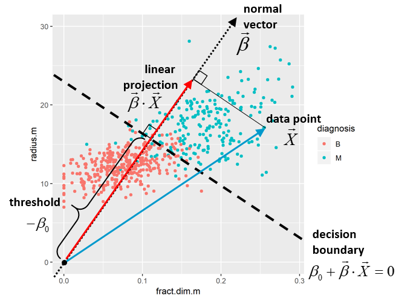

## Linear Classifiers

- Several ways to find linear decision boundary
  - Logistic Regression
  - Linear Discriminant Analysis (LDA)
  - Support Vector Machines (SVM)
- All methods produce *normal vector* of linear coefficients (\(\vec{\beta}\))
- We will focus on logistic regression

## Logistic Regression

- Fit logistic regression with `glm()`

```r
glm_out = glm( diagnosis ~ fract.dim.m + radius.m, family = "binomial",
  data = wdbc %>% mutate( diagnosis = factor(diagnosis)) )
broom::tidy(glm_out)
## # A tibble: 3 x 5
##   term        estimate std.error statistic  p.value
##   <chr>          <dbl>     <dbl>     <dbl>    <dbl>
## 1 (Intercept)  -18.6       2.06      -9.01 1.99e-19
## 2 fract.dim.m   52.1       6.36       8.19 2.69e-16
## 3 radius.m       0.811     0.122      6.65 2.84e-11
```

- Decision boundary \(-18.59 + 52.06 X_1 + 0.81 X_2 = 0\)

## Logistic Regression

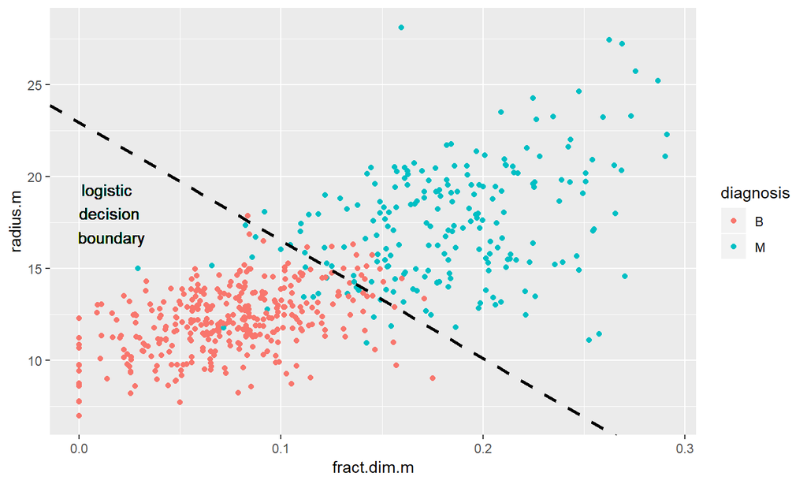

## Logistic Regression

- `predict()` returns *distance* from *decision boundary*
  - i.e. projection + threshold

```r
( glm_pred = predict(glm_out) ) %>% sample(5)
##       164       448       232       500       532
## -4.317983 -2.263426 -8.326930  9.108325 -4.899920

wdbc %>% modelr::add_predictions(glm_out, var = "distance") %>%
  mutate( predicted = ifelse(distance < 0, "B", "M")  ) %>%
  xtabs(~ predicted + diagnosis, data = .) %>% prop.table()
##          diagnosis
## predicted          B          M
##         B 0.60105448 0.03514938
##         M 0.02636204 0.33743409
```

## Logistic Regression

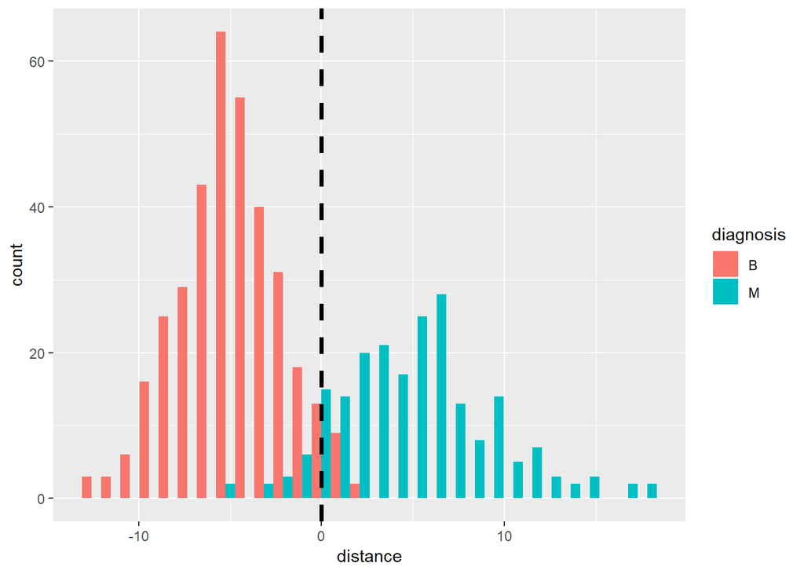

## Single vs Multiple Features

- Compare ROC curves

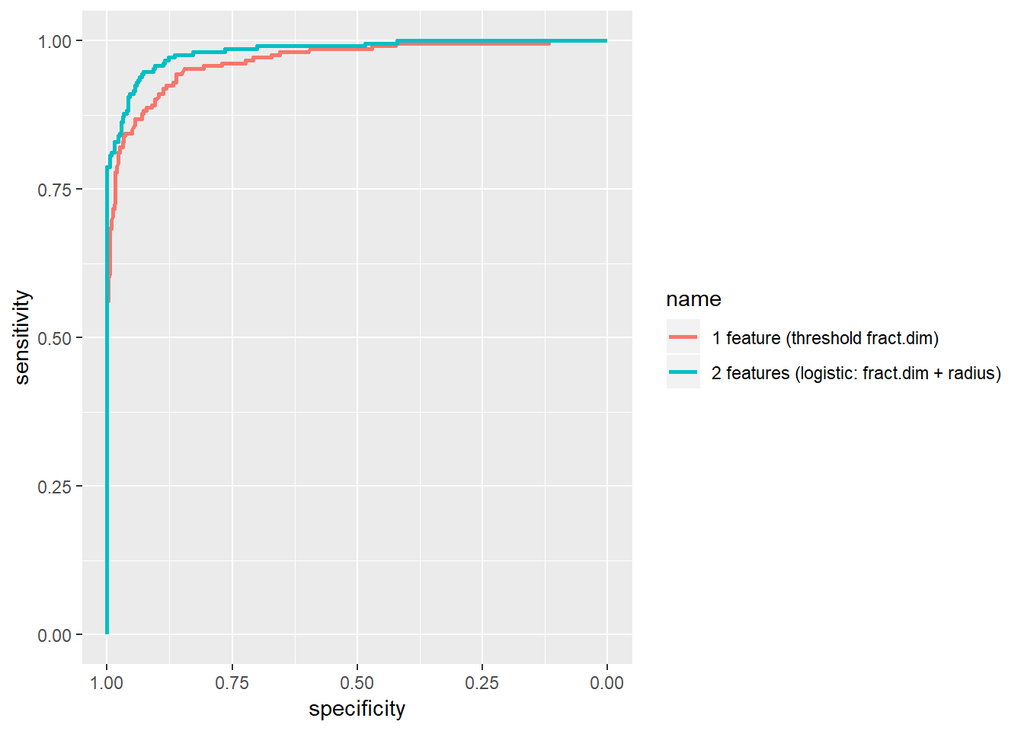

## Nonlinear Classifiers

- Classifier with *nonlinear* decision boundaries

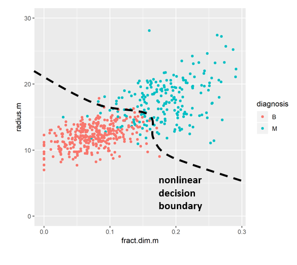

## Nearest Neighbor (NN)

- Basics nonlinear classifier: classify each point like its *nearest neighbor*

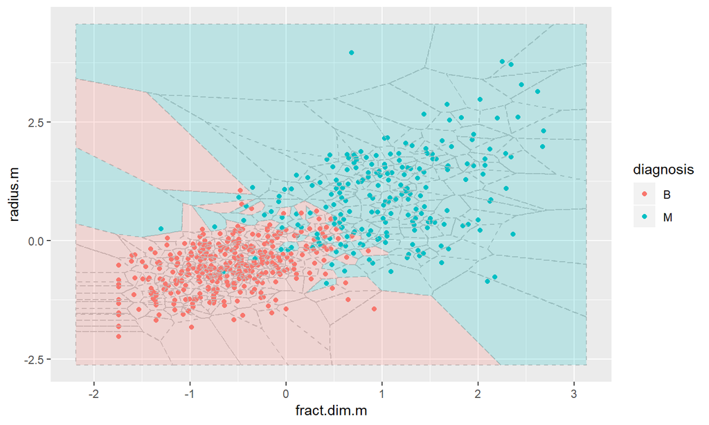

## Classification Tree

- Threshold different variables in *nested/hierarchical* manner

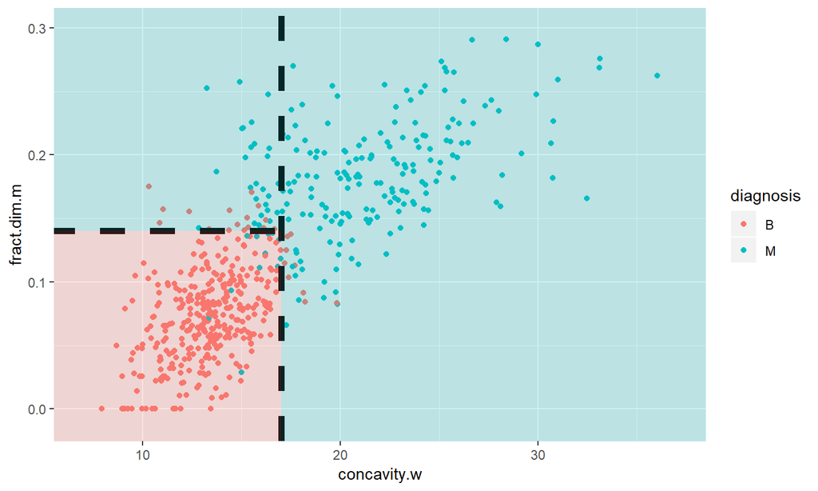

## Classification Tree

- Fit tree using library `rpart` (recursive partitioning)

```r
library(rpart)
rpart_out = rpart( diagnosis ~ . - id, data = wdbc,
    method = "class", control = rpart.control(minsplit=50) )
rpart_out
## n= 569
##
## node), split, n, loss, yval, (yprob)
##       * denotes terminal node
##
## 1) root 569 212 B (0.62741652 0.37258348)
##   2) concavity.w< 16.795 379  33 B (0.91292876 0.08707124)
##     4) fract.dim.m< 0.1358 333   5 B (0.98498498 0.01501502) *
##     5) fract.dim.m>=0.1358 46  18 M (0.39130435 0.60869565) *
##   3) concavity.w>=16.795 190  11 M (0.05789474 0.94210526) *
```

## Classification Tree

- Plot tree using library `rpart.plot`

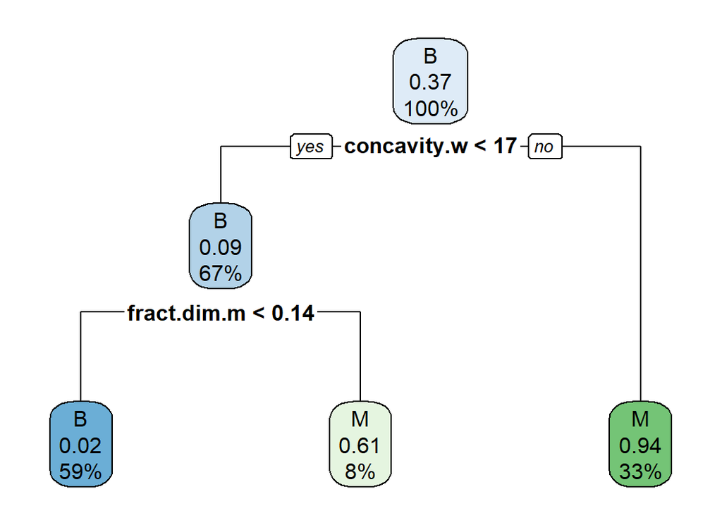

```r
library(rpart.plot); rpart.plot(rpart_out)
```

## Classification Tree Predictions

- `predict()` gives class *probabilities*
  - Use `type = "class"` to get classes

```r
predict(rpart_out) %>% head(2)
##            B         M
## 1 0.05789474 0.9421053
## 2 0.05789474 0.9421053

wdbc %>% modelr::add_predictions( rpart_out, type = "class" ) %>%
  xtabs( ~ pred + diagnosis, data = .) %>% prop.table()
##     diagnosis
## pred           B           M
##    B 0.576449912 0.008787346
##    M 0.050966608 0.363796134
```